# ASTRO 530 Homework 5 - Olivier Gilbert - November 18 2025

## 1. Gap opening condition

### a)

The gap opening timescale is $$t_\mathrm{open} = \frac{\Delta J}{\left|\frac{\mathrm{d}J}{\mathrm{d}t}\right|}$$

where $\Delta J = 2\pi a w \Sigma \left.\frac{\mathrm{d}l}{\mathrm{d}r}\right|_a w$, with $l=\sqrt{GM_s r}$. With the approximation of an impulse, we can also use

$$\frac{\mathrm{d}J}{\mathrm{d}t}=-\frac{8}{27}\frac{G^2 M_p^2 a \Sigma}{\Omega_p^2 w^3}$$

We can therefore start solving for $t_\mathrm{open}$:

$$\left.\frac{\mathrm{d}l}{\mathrm{d}r}\right|_a = \left.\frac{\mathrm{d}\sqrt{GM_s r}}{\mathrm{d}r}\right|_a = \frac{1}{2}\sqrt{\frac{GM_s}{a}}$$

$$t_\mathrm{open} = \frac{\Delta J}{\left|\frac{\mathrm{d}J}{\mathrm{d}t}\right|}$$ $$t_\mathrm{open} = \frac{2\pi a w \Sigma \left.\frac{\mathrm{d}l}{\mathrm{d}r}\right|_a w}{\frac{8}{27}\frac{G^2 M_p^2 a \Sigma}{\Omega_p^2 w^3}}$$ $$t_\mathrm{open} = \frac{2\pi a w \Sigma \frac{1}{2}\sqrt{\frac{GM_s}{a}} w}{\frac{8}{27}\frac{G^2 M_p^2 a \Sigma}{\Omega_p^2 w^3}}$$ $$t_\mathrm{open} = \frac{27 \pi \Omega_p^2 w^5 \sqrt{\frac{GM_s}{a}}}{8G^2 M_p^2}$$

And we know that for a Keplerian orbit at $r=a$, $\Omega_p=\sqrt{\frac{GM_s}{a^3}}$: $$t_\mathrm{open} = \frac{27 \pi \frac{GM_s}{a^3} w^5 \sqrt{\frac{GM_s}{a}}}{8G^2 M_p^2}$$ $$t_\mathrm{open} = \frac{27 \pi w^5}{8 M_p^2} \sqrt{\frac{M_s^3}{Ga^7}}$$

## b)

The timescale to close the gap is $t_\mathrm{close} = w^2/\nu$, and using an alpha disk $\nu = \alpha c_s H$ with the assumption the width of the gap $w$ needs to be equal to the scale height of the disk $H$, we can calculate the minimum mass a planet must be to open a gap. We simply need to solve for $M_p$ while equating the opening and closing timescale:

$$t_\mathrm{open} = t_\mathrm{close}$$ $$\frac{27 \pi w^5}{8 M_p^2} \sqrt{\frac{M_s^3}{Ga^7}} = \frac{w^2}{\nu}$$ $$\frac{27 \pi w^5}{8 M_p^2} \sqrt{\frac{M_s^3}{Ga^7}} = \frac{w^2}{\alpha c_s H}$$ $$\frac{27 \pi H^4}{8 } \sqrt{\frac{M_s^3}{Ga^7}} = \frac{M_p^2}{\alpha c_s}$$ $$M_p = \left[\frac{27 \pi H^4 \alpha c_s}{8 } \sqrt{\frac{M_s^3}{Ga^7}}\right]^{1/2}$$ We can also replace $c_s$ to be $H \Omega_K$, with $\Omega_K=\sqrt{\frac{GM_s}{a^3}}$ at $r=a$: $$M_p = \left[\frac{27 \pi H^4 \alpha H\sqrt{\frac{GM_s}{a^3}}}{8 } \sqrt{\frac{M_s^3}{Ga^7}}\right]^{1/2}$$ $$M_p = \left[\frac{27 \pi H^5 \alpha }{8 } \sqrt{\frac{M_s^4}{a^10}}\right]^{1/2}$$ $$M_p = \left[\frac{27 \pi H^5 \alpha M_s^2 }{8a^5 }\right]^{1/2}$$

We have therefore found that, to carve a gap, the planetary mass must be $$M_p \geq \left[\frac{27 \pi H^5 \alpha M_s^2 }{8a^5 }\right]^{1/2}$$

### c)

Assuming a characteristic $\frac{H}{r}\sim0.05$, $\alpha\sim 10^{-3}$, and $M_s=M_\odot$, we can calculate the planet mass needed to open a gap:

$$M_p \geq \left[\frac{27 \pi H^5 \alpha M_s^2 }{8a^5 }\right]^{1/2}$$ We can replace the values of $M_s$ and $\alpha$, and use $\frac{H}{r} = \frac{H}{a}\to H=0.05a$:

$$M_p \geq \left[\frac{27 \pi 0.05^5 \cdot 10^{-3}\cdot M_\odot^2 }{8 }\right]^{1/2}$$

We can now calculate this, which gives us $19.17 M_\oplus = 1.12 M_\mathrm{neptune} = 0.06 M_\mathrm{jupiter}$.

```python
import astropy.units as u
from astropy.constants import M_sun, M_earth, M_jup
import numpy as np
M_nep = 1.024E26*u.kg
M_p = (27*np.pi*0.05**5*1E-3*M_sun**2/8)**(1/2)
print(M_p/M_earth)
print(M_p/M_nep)
print(M_p/M_jup)
```

```
19.165084552077612
1.117745138138895
0.06030009953301236
```

## 2. Planetary cooling evolution

### a)

We want to calculate the equilibrium temperatures of Jupiter, Saturn, Uranus, and Neptune. We will assume an effective temperature of the Sun of $T_\mathrm{eff}=5870\mathrm{K}$, and a radius of $R=6.96\times 10^{10}\mathrm{cm}$. For the planets, we will use

| Planet | Semi-major axis (AU) | Bond albedo |
| --- | --- | --- |
| Jupiter | 5.20 | 0.343 |
| Saturn | 9.58 | 0.342 |
| Uranus | 19.2 | 0.300 |
| Neptune | 30.0 | 0.290 |

$$T_\mathrm{eq} = (1-A_B)^{1/4}\left(\frac{R_s}{2a}\right)^{1/2}T_{s,\mathrm{eff}}$$ $$T_\mathrm{eq,\mathrm{Jupiter}} = 111.77\mathrm{K}$$ $$T_\mathrm{eq,\mathrm{Saturn}} = 82.38\mathrm{K}$$ $$T_\mathrm{eq,\mathrm{Uranus}} = 59.10\mathrm{K}$$ $$T_\mathrm{eq,\mathrm{Neptune}} = 47.45\mathrm{K}$$

```python
import astropy.units as u
T_eff_sun = 5870*u.K
R_sun = 6.96E10 *u.cm
def T_eq(a:float,A_B:float) -> float:
    return ((1-A_B)**(1/4)*(R_sun/(2*a))**(1/2)*T_eff_sun).to(u.K)
print("T_eq,jup:", T_eq(5.20*u.AU, 0.343))
print("T_eq,sat:", T_eq(9.58*u.AU, 0.342))
print("T_eq,ura:", T_eq(19.2*u.AU, 0.300))
print("T_eq,nep:", T_eq(30.0*u.AU, 0.290))
```

```
T_eq,jup: 111.77757611985153 K
T_eq,sat: 82.38321496114885 K
T_eq,ura: 59.100194866587735 K
T_eq,nep: 47.44811646310739 K
```

### b)

We will now calculate the internal temperature of each planet: $$4\pi R_p^2 \sigma T_\mathrm{int}^4 = L_\mathrm{int}$$

Where $$L_\mathrm{int} = 4\pi R_p^2 \sigma (T_\mathrm{eff}^4-T_\mathrm{eq}^4)$$ So we have $$4\pi R_p^2 \sigma T_\mathrm{int}^4 = 4\pi R_p^2 \sigma (T_\mathrm{eff}^4-T_\mathrm{eq}^4)$$ $$T_\mathrm{int}^4 = (T_\mathrm{eff}^4-T_\mathrm{eq}^4)$$

$$T_\mathrm{int,\mathrm{Jupiter}} = 96.86\mathrm{K}$$ $$T_\mathrm{int,\mathrm{Saturn}} = 77.12\mathrm{K}$$ $$T_\mathrm{int,\mathrm{Uranus}} = 29.53\mathrm{K}$$ $$T_\mathrm{int,\mathrm{Neptune}} = 53.00\mathrm{K}$$

```python
def T_int(T_eff:float, T_eq:float) -> float:
    return (T_eff**4-T_eq**4)**(1/4)
T_int_jup = T_int(125*u.K, T_eq(5.20*u.AU, 0.343))
T_int_sat = T_int(95*u.K, T_eq(9.58*u.AU, 0.342))
T_int_ura = T_int(60*u.K, T_eq(19.2*u.AU, 0.300))
T_int_nep = T_int(60*u.K, T_eq(30.0*u.AU, 0.290))
print("T_int,jup:", T_int_jup)
print("T_int,sat:", T_int_sat)
print("T_int,ura:", T_int_ura)
print("T_int,nep:", T_int_nep)
```

```
T_int,jup: 96.86430216984326 K
T_int,sat: 77.12798180109372 K
T_int,ura: 29.527057432210874 K
T_int,nep: 53.001780484401785 K
```

### c)

We will now calculate the internal temperature of each planet as a function of the age of the Solar System, assuming their radius and luminosity stayed constant.

$$-L = M_p c_v \frac{\mathrm{d}T_\mathrm{int}}{\mathrm{d}t}$$ $$\frac{\mathrm{d}T_\mathrm{int}}{\mathrm{d}t} = -\frac{L}{M_p c_v} $$ $$\mathrm{d}T_\mathrm{int} = -\frac{L}{M_p c_v}\mathrm{d}t $$ $$\int\mathrm{d}T_\mathrm{int} = -\int\frac{L}{M_p c_v}\mathrm{d}t $$ $$T_\mathrm{int} = -\frac{L}{M_p c_v}t + T_0$$ where $T_0$ is a constant. We can evaluate that constant, knowing the current internal temperature, and the current age of the solar system (4.603Gyr). $$T_\mathrm{int,current} = -\frac{L}{M_p c_v}\cdot4.603\mathrm{Gyr} + T_0$$ $$T_0 = T_\mathrm{int,current}+\frac{L}{M_p c_v}\cdot4.603\mathrm{Gyr}$$

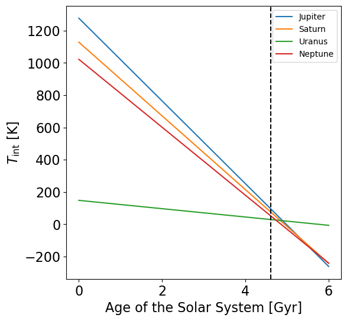

```python
from astropy.constants import k_B, sigma_sb, R_jup
import matplotlib.pyplot as plt
import matplotlib as mpl
mpl.rcParams['xtick.labelsize'] = 16
mpl.rcParams['ytick.labelsize'] = 16
plt.rc("axes", labelsize=16)

c_v_J_S = (2.5*k_B/(u.u)).to(u.erg/u.g/u.K)
c_v_U_N = (3.0*k_B/(5*u.u)).to(u.erg/u.g/u.K)

current_age_solar_system = 4.603*u.Gyr
M_nep = 1.024E26*u.kg
M_sat = 5.683E26*u.kg
M_ura = 8.681E25*u.kg
R_nep = 24622*u.km
R_sat = 58232*u.km
R_ura = 25559*u.km
Masses = [M_jup, M_sat, M_ura, M_nep]
Temps = [T_int_jup, T_int_sat, T_int_ura, T_int_nep]
Radii = [R_jup, R_sat, R_ura, R_nep]
Luminosities = [4*np.pi*sigma_sb*Radii[i]**2*Temps[i]**4 for i in range(4)] # Assume the luminosities are constant over time (even though they should depend on T_int^4)
c_vs = [c_v_J_S,c_v_J_S,c_v_U_N,c_v_U_N]
names = ["Jupiter","Saturn","Uranus","Neptune"]
def T_int_ev(t,T_int_curr,M_p,L,c_v):
    return (-L/(M_p*c_v)*t + T_int_curr + L/(M_p*c_v)*current_age_solar_system).to(u.K)

timerange = np.linspace(0,6,1000)*u.Gyr
plt.figure(figsize=(6,6))
for i in range(4):
    T_int_fn = lambda t: T_int_ev(t,Temps[i],Masses[i],Luminosities[i],c_vs[i])
    plt.plot(timerange, T_int_fn(timerange), marker="None", label=names[i])
plt.axvline(current_age_solar_system.value, ls="--", color="black")
plt.legend()
plt.xlabel("Age of the Solar System [Gyr]")
plt.ylabel(r"$T_\mathrm{int}$ [K]")
plt.show()
```

### d)

We expect the radius of each planet to diminish with time, which would affect the ability of the planet to cool, as the luminosity is proportional to $L\propto R_p^2$. This would therefore reduce the effectiveness of the cooling, which would augment the cooling timescale. The plot in c) would then lose its linear look and show a shallower dependence on the time elapsed.

### e)

We would expect the luminosity to get smaller with time, because it is proportional to $L\propto R_p^2 T_\mathrm{int}^4$. We have already explained that the radius will become smaller with time, which already contributes to the diminishing of the luminosity, but the internal temperature will also, by definition, become colder as time goes by, which will contribute to a smaller luminosity. This will make for a much shallower slope than presented on c), with a dependence on time that is not linear, but more asymptotical.

It would be possible to show that exact trend by doing our integration to find $T_\mathrm{int}$ again, but replacing $L$ by its expression dependent on $T_\mathrm{int}$:

$$\int\mathrm{d}T_\mathrm{int} = -\int\frac{4\pi \sigma R_p(t)^2 T_\mathrm{int}^4}{M_p c_v}\mathrm{d}t $$ $$\int \frac{1}{T_\mathrm{int}^4}\mathrm{d}T_\mathrm{int} = -\int\frac{4\pi \sigma R_p(t)^2 }{M_p c_v}\mathrm{d}t $$

This would be a more accurate way to show the evolution of the internal temperature of the planets.

## 3. Asynchronous “bonus” lecture

### a)

I watched *Summary and Discussion: Debris Disks as Planetary Signposts (Theory and Observations)* from Mark Wyatt and Alycia Weinberger.

### b)

Something interesting I learned from this lecture is that disks around a very inclined planet can be disturbed to the point where they are locally warped, and even orthogonal compared to the rest of the disk. I also knew that we used infrared observations to observe scattered starlight to infer the structure of the disk, but I learned that one of the reason for this is because that scattered light can be observed at a much higher resolution than optical, and even radio light. Alycia Weinberger mentions the resolution of tens of milliarcseconds that is now possible in the infrared is even higher than ALMA's resolution.

Another thing I learned is that the excess of far-IR emission observed that is usually attributed to the dust can actually be caused by the star sometimes. In resolved images, we can see the star has an excess that was found to be caused by stellar flares, not its blackbody continuum.

Additionally, I learned that the collisions between planetesimals grind them together, which creates smaller rocks, which makes the collision probability higher, etc., until the distribution of the planetesimals exhibits a clear majority of the particles to have a micron-scale size. This dust is then disturbed by radiation pressure, which makes their excentricity much higher, and this creates a halo of dust outside the planetesimal belt. This is completely new to me, as I didn't even know there was a halo of dust at a large distance from the star.

### c)

From the lectures, we have learned that there is a minimum planetary mass for which a gap will form in the disk that would otherwise stay closed (no gap). From this talk, I learned that it is possible for a system to have a gap, but not around the whole $2\pi$ of the circular orbit. This is interesting, because it shows that there is probably a range of planetary masses that are too small to carve a gap that will last for a complete orbit without the disk covering it completely again, but large enough to still carve a gap that spans the total height of the disk so that there is no gas flowing over/under the planet. (Shown $\sim$ 6min into the video)

We have also learned about gravitational instabilities causing pressure gradients in the dust/gas of the disk, but this talk showed that dust drifting inward can get trapped in resonances of planets (seemingly at Lagrange points from the figure shown at 12m29s). This expands on the idea of planetesimals getting trapped in resonances and migrating with the planet that we saw in class. These would provide additional evidence of the presence of a planet.

### d)

I would recommend this talk to my peers, because it was very interesting to learn about the material we've been learning in class in a different setting. Instead of learning what was already known, this talk shows how the relatively simple material we've learned can be applied to the frontier of research in this area, while being easy to follow conceptually. I think it was also a valuable watch since it helped me put into perspective what we've learned and all the assumptions we've been using compared to the actual observations, where the complexity of the systems definitely needs more attention to details than we've been assuming all throughout our derivations.

Even as a student that doesn't research exoplanets or star formation, the observational techniques that were presented by Alycia Weinberg were very interesting, and could be applied to other astonomy fields. The PCA used to remove the star light could potentially be applied to resolved AGN disks with the Event Horizon Telescope, for example, which makes this talk useful.